# ExpHunterSuite: Differential Expression Report

## **Detailed package results comparation**

This is an advanced section in order to compare the output of the packages used to perform data analysis. The data shown here does not necessarilly have any biological implication.

### **P-value Distributions**

Distributions of p-values, unadjusted and adjusted for multiple testing (FDR)

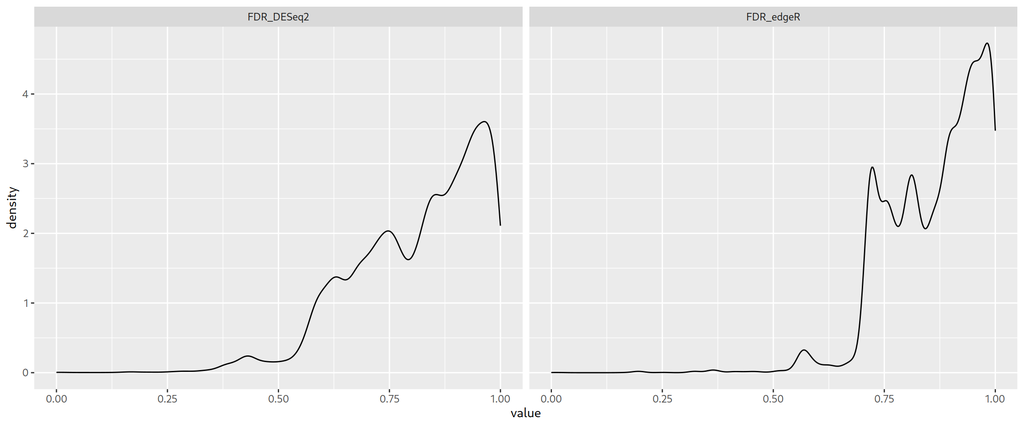

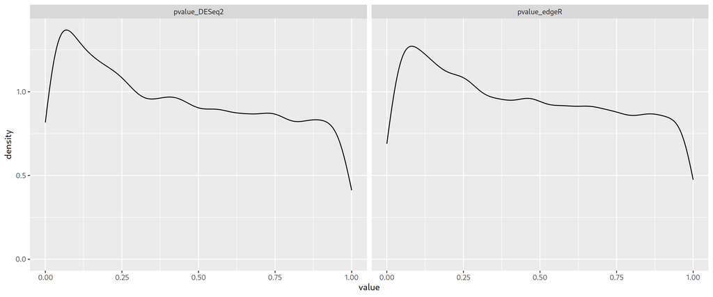

### **FDR Correlations**

Correlations of adjusted p-values, adjusted for multiple testing (FDR) and for log Fold Change.

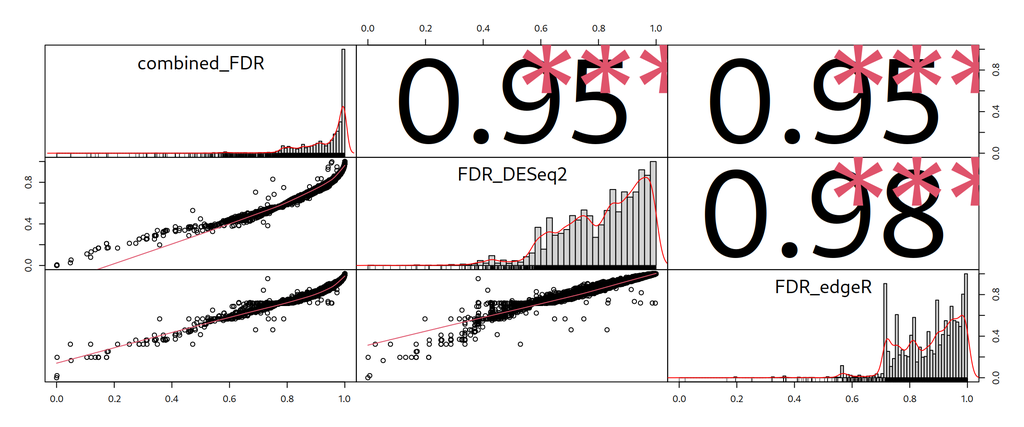

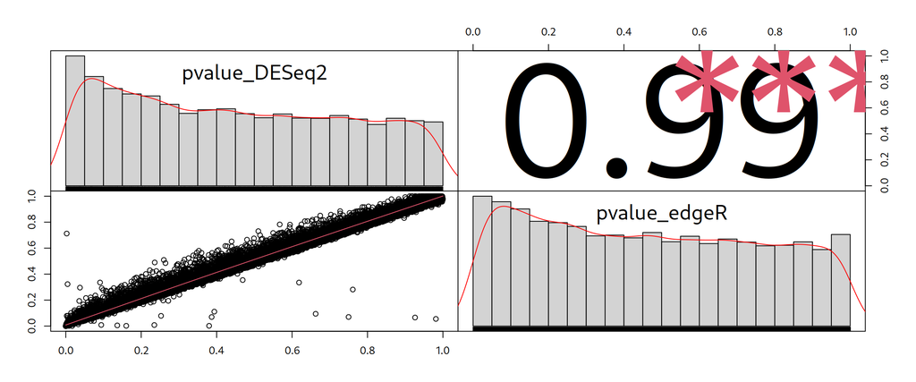

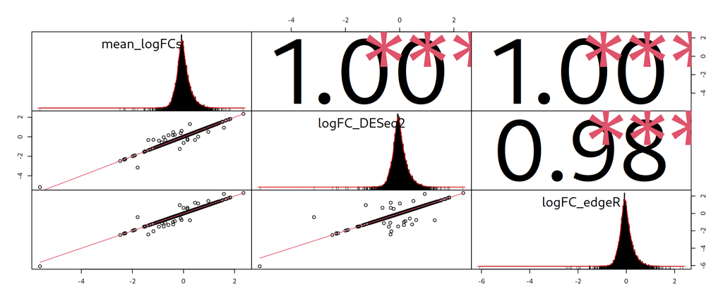

### **Values of options used to run DEGenesHunter**

First column contains the option names; second column contains the given values for each option in this run.

|  | opt |
| --- | --- |
| input_file | /mnt/home/users/bio_369_uma/jmperez/hunter/case2/count_table.txt |
| pseudocounts | FALSE |
| reads | 2 |
| count_var_quantile | 0 |
| minlibraries | 2 |
| filter_type | separate |
| output_files | /mnt/home/users/bio_369_uma/jmperez/hunter/case2/results_f06/ |
| p_val_cutoff | 0.05 |
| lfc | 0.6 |
| modules | DE |
| minpack_common | 4 |
| target_file | target_file |
| model_variables |  |
| numerics_as_factors | FALSE |
| string_factors |  |
| numeric_factors |  |
| WGCNA_memory | 5000 |
| WGCNA_norm_method | DESeq2 |
| WGCNA_deepsplit | 2 |
| WGCNA_min_genes_cluster | 20 |
| WGCNA_detectcutHeight | 0.995 |
| WGCNA_mergecutHeight | 0.25 |
| WGCNA_all | FALSE |
| WGCNA_blockwiseNetworkType | signed |
| WGCNA_blockwiseTOMType | signed |
| WGCNA_minCoreKME | 0.7 |
| WGCNA_minKMEtoStay | 0.5 |
| WGCNA_corType | pearson |
| multifactorial |  |
| help | FALSE |